# Estudios de Informática, Multimedia y Telecomunicaciones

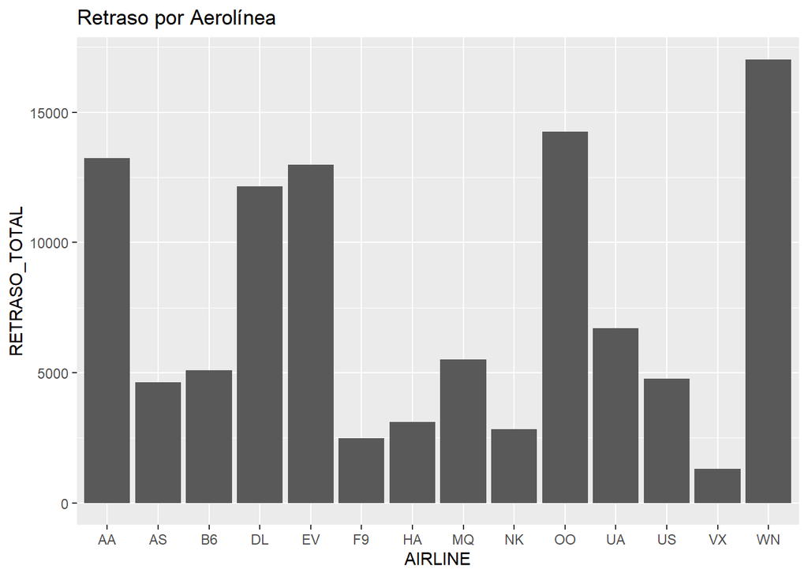

```r
vuelos_reduc %>%
  filter( RETRASO_TOTAL>0) %>%
  ggplot(aes(AIRLINE,fill=RETRASO_TOTAL))+geom_bar() +labs(x="AIRLINE", y="RETRASO_TOTAL")+ guides(fill=guide_legend(title=""))+ scale_fill_manual(values=c("black","#008000"))+ggtitle("Retraso por Aerolínea")
```

Comprobamos que los resultados entre los retrasos tanto de llegada como de salida por aerolínea son prácticamente iguales, por lo que Southwest Airlines fue la que más retrasos tuvo en las llegadas. Por otro lado, es lógico que si un vuelo se retrasa en la salida, se retrase también en la llegada.

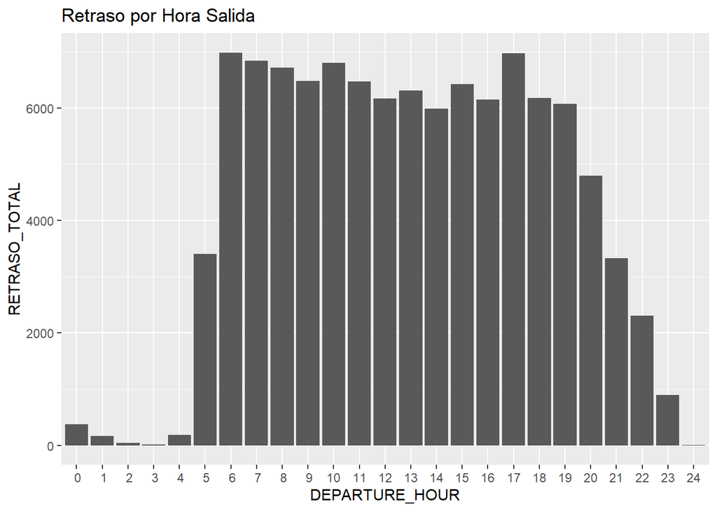

```r
vuelos_reduc %>%
  filter( RETRASO_TOTAL>0) %>%
  ggplot(aes(DEPARTURE_HOUR,fill=RETRASO_TOTAL))+geom_bar() +labs(x="DEPARTURE_HOUR", y="RETRASO_TOTAL")+ guides(fill=guide_legend(title=""))+ scale_fill_manual(values=c("black","#008000"))+ggtitle("Retraso por Hora Salida")
```

En cuanto al retraso por hora de salida, podemos identificar que las horas más problemáticas se tienen en la franja entre las 6am y las 7pm, siendo las 6am, las 10am y las 5pm las horas que acumulan mayor retraso.En esta gráfica vemos totales, no porcentajes, y es lógico que en las horas de más afluencia haya más vuelos retrasados.

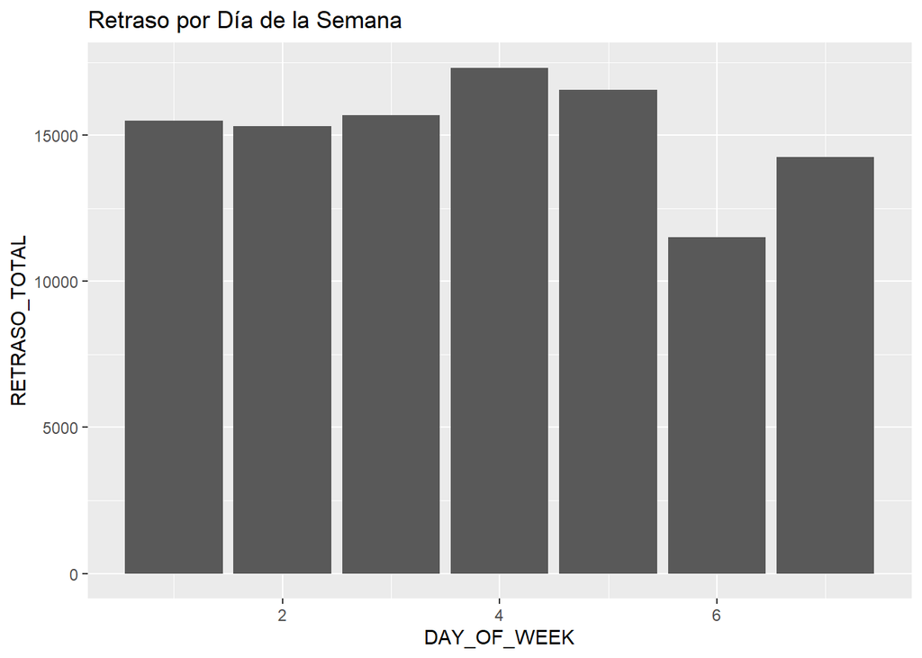

```r
vuelos_reduc %>%
  filter( RETRASO_TOTAL>0) %>%
  ggplot(aes(DAY_OF_WEEK,fill=RETRASO_TOTAL))+geom_bar() +labs(x="DAY_OF_WEEK", y="RETRASO_TOTAL")+ guides(fill=guide_legend(title=""))+ scale_fill_manual(values=c("black","#008000"))+ggtitle("Retraso por Día de la Semana")
```

Según el gráfico podemos decir que los días donde se concentra el mayor número de retrasos son el jueves y el viernes. Según esto, el mejor día para viajar sería el sábado, también coincidiendo con el día de menos afluencia de vuelos.

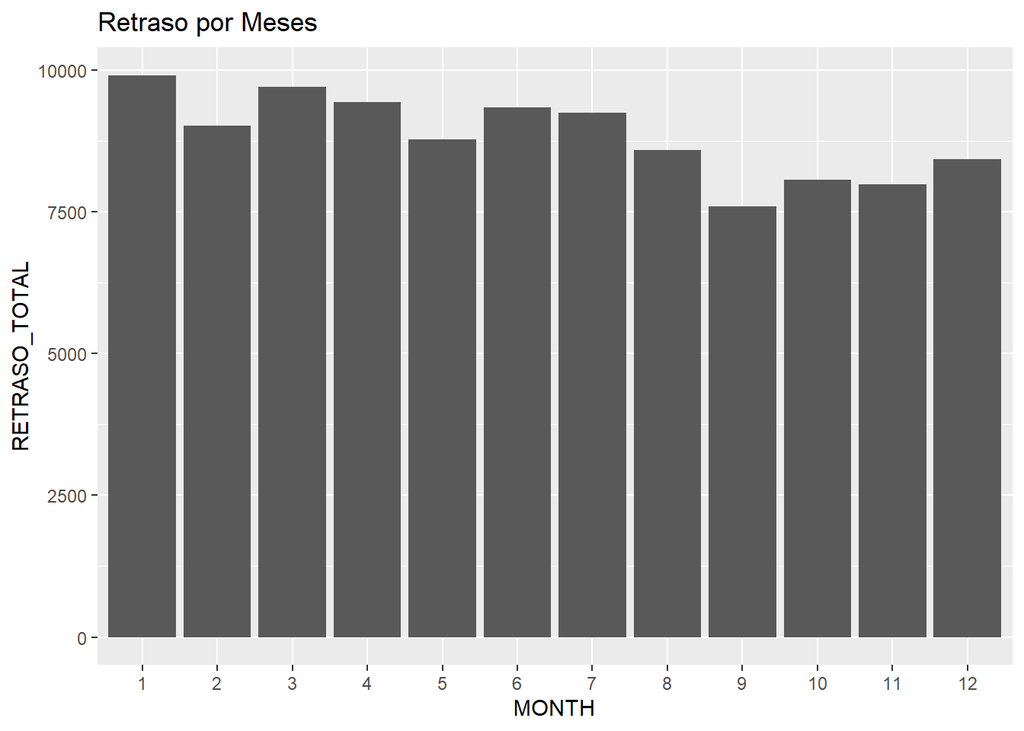

```r
vuelos_reduc %>%
  filter( RETRASO_TOTAL>0) %>%
  ggplot(aes(factor(MONTH),fill=RETRASO_TOTAL))+geom_bar() +labs(x="MONTH", y="RETRASO_TOTAL")+ guides(fill=guide_legend(title=""))+ scale_fill_manual(values=c("black","#008000"))+ggtitle("Retraso por Meses")
```

Según el gráfico, parece que el mes con más retrasos es enero, algo que no es lo que podríamos esperar en un inicio, tendríamos que hacer un estudio de las causas de los retrasos para poder valorar bien este dato. Los mejores meses para viajar parecen ser los meses de septiembre, octubre y noviembre. Al ver la gráfica en porcentaje, observaremos que la distribución de vuelos retrasados por porcentaje es algo diferente y nos decuelve otros resultados.

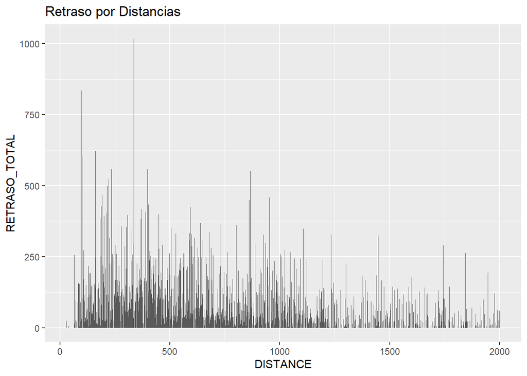

```r
vuelos_reduc %>%
  filter( RETRASO_TOTAL>0 & DISTANCE<2000) %>%
  ggplot(aes(DISTANCE,fill=RETRASO_TOTAL))+geom_bar() +labs(x="DISTANCE", y="RETRASO_TOTAL")+ guides(fill=guide_legend(title=""))+ scale_fill_manual(values=c("black","#008000"))+ggtitle("Retraso por Distancias")
```

Comprobamos que los mayores retrasos se tienen en distancias más cortas, distancias menores de 1000 millas, y se tienen picos de retraso en distancias menores de 500 millas. Vamos a centrar un poco más el gráfico para comprobar que distancias dan esos picos de retraso.

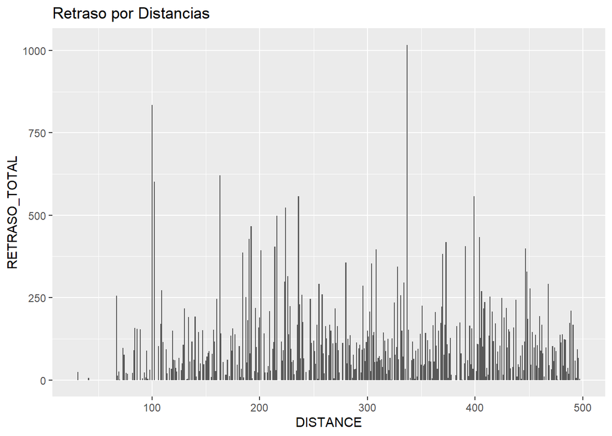

```r
vuelos_reduc %>%
  filter( RETRASO_TOTAL>0 & DISTANCE<500) %>%
  ggplot(aes(DISTANCE,fill=RETRASO_TOTAL))+geom_bar() +labs(x="DISTANCE", y="RETRASO_TOTAL")+ guides(fill=guide_legend(title=""))+ scale_fill_manual(values=c("black","#008000"))+ggtitle("Retraso por Distancias")
```

A continuación, vamos a ver varias gráficas que nos aportan información en % con lo que podemos sacar mejores conclusiones sobre los retrasos y las aerolíneas, aeropuertos, etc. Para ello vamos a trabajar con el conjunto original de datos, por lo que los resultados obtenidos serán los reales el año 2015.

Comenzaremos obteniendo un conjunto de datos que no contenga datos desconocidos para poder estimar los porcentajes:

```r
indice <- which(is.na(vuelos$AIR_SYSTEM_DELAY)) #locations of obs with missing values
vuelos_delay <- vuelos[-indice,]
dim(vuelos_delay)
```

```
## [1] 1063439      31
```

Lo que vamos a hacer ahora es ver los vuelos que no sufren retrasos de nuestro dataset.

```r
vuelos_no_delay <- vuelos[indice,]
dim(vuelos_no_delay)
```

```
## [1] 4755640      31
```

```r
head(vuelos_no_delay)
```

```
##   YEAR MONTH DAY DAY_OF_WEEK AIRLINE FLIGHT_NUMBER TAIL_NUMBER ORIGIN_AIRPORT
## 1 2015     1   1           4      AS            98      N407AS            ANC
## 2 2015     1   1           4      AA          2336      N3KUAA            LAX
## 3 2015     1   1           4      US           840      N171US            SFO
## 4 2015     1   1           4      AA           258      N3HYAA            LAX
## 5 2015     1   1           4      AS           135      N527AS            SEA
## 6 2015     1   1           4      DL           806      N3730B            SFO
##   DESTINATION_AIRPORT SCHEDULED_DEPARTURE DEPARTURE_TIME DEPARTURE_DELAY
## 1                 SEA                   5           2354             -11
## 2                 PBI                  10              2              -8
## 3                 CLT                  20             18              -2
## 4                 MIA                  20             15              -5
## 5                 ANC                  25             24              -1
## 6                 MSP                  25             20              -5
##   TAXI_OUT WHEELS_OFF SCHEDULED_TIME ELAPSED_TIME AIR_TIME DISTANCE WHEELS_ON
```

[output cut: 27 more lines]

Tenemos 1063439 vuelos que sufrieron retrasos frente a los 4755640 que no sufrieron retrasos, por lo que la probabilidad de que un vuelo se retrasara en el 2015 fue del 18.27%

Ahora, mostraremos una gráfica de barras donde podemos ver el porcentaje de retrasos de cada aerolínea:

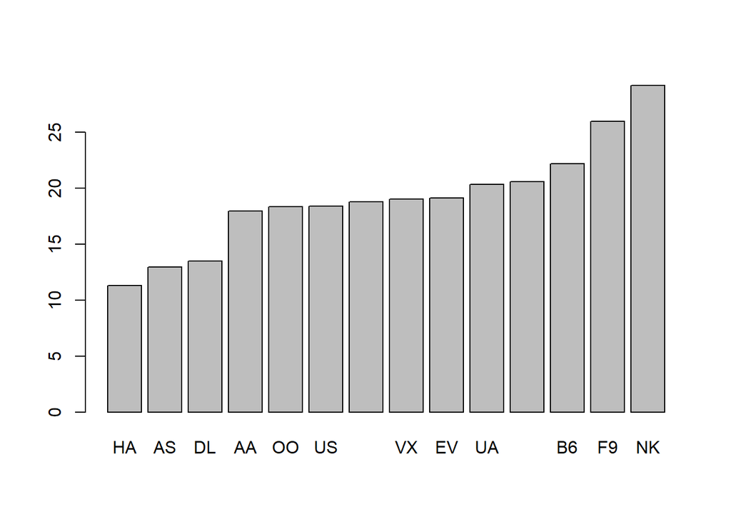

```r
barplot(sort(table(vuelos_delay$AIRLINE) / table(vuelos$AIRLINE) * 100))
```

Vemos que la que mayor porcentaje de vuelos retrasados tiene es NK. Esta gráfica nos aporta una información más valiosa que la anterior donde veíamos los retrasos totales por compañías, ya que en la anterior obteníamos que la que más retrasos registraba era WN, pero este dato se debía a que es la compañía que más opera en Estados Unidos.

Los porcentajes exactos los vemos en la siguiente tabla:

```r
sort((table(vuelos_delay$AIRLINE) / table(vuelos$AIRLINE) * 100)) %>% knitr::kable("html")  %>% kable_styling(position='center', font_size=12, fixed_thead=list(enabled=T))
```

| Var1 | Freq |
| --- | --- |
| HA | 11.29903 |
| AS | 12.95610 |
| DL | 13.47478 |
| AA | 17.94516 |
| OO | 18.32148 |
| US | 18.39267 |
| WN | 18.75223 |
| VX | 19.02654 |
| EV | 19.08888 |
| UA | 20.30586 |
| MQ | 20.55004 |
| B6 | 22.15894 |
| F9 | 25.94786 |
| NK | 29.15428 |

Apreciamos que NK tiene un 29.15 % de vuelos retrasados, frente al 11.29 de HA que es la que menor porcentaje presenta.

Ahora lo que analizaremos será el porcentaje de vuelos retrasados según los meses:

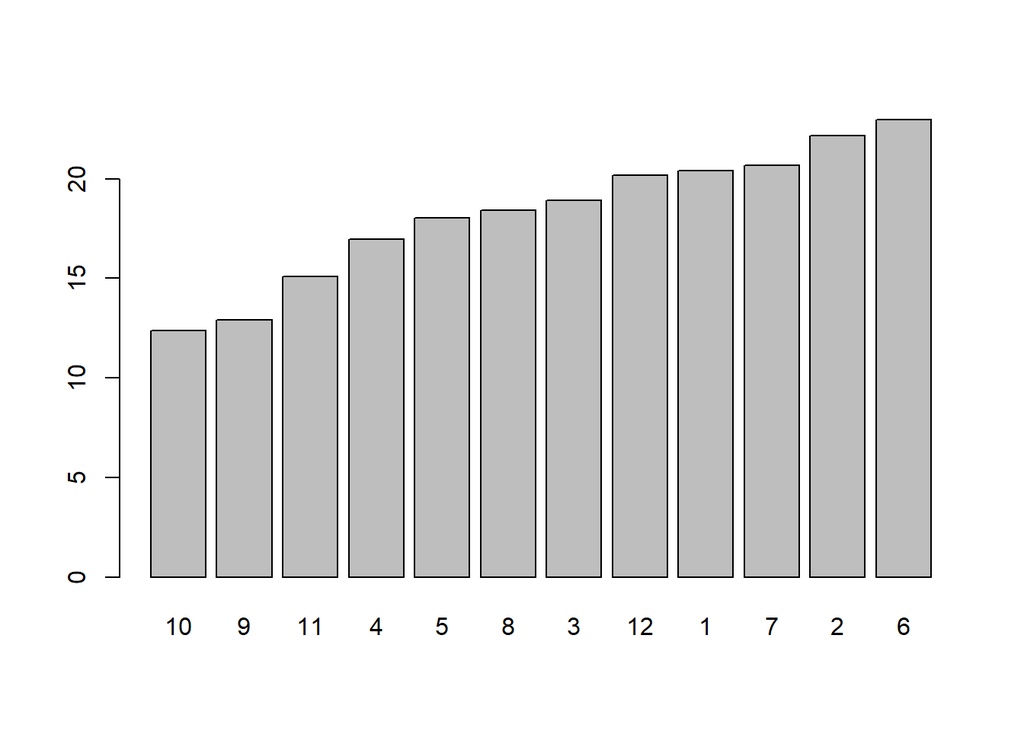

```r
barplot(sort(table(vuelos_delay$MONTH) / table(vuelos$MONTH) * 100))
```

```r
table(vuelos_delay$MONTH) / table(vuelos$MONTH) * 100
```

```
##
##        1        2        3        4        5        6        7        8
## 20.41650 22.17637 18.92717 16.95287 18.03748 22.96938 20.66896 18.43416
##        9       10       11       12
## 12.91784 12.35774 15.08018 20.19323
```

Vemos como el mes de junio es el que presenta más retrasos. Un dato curioso que obtenemos de esta gráfica es que observamos que el mes con mayor % de retrasos no se corresponde con el mes con mayor número de vuelos. En una gráfica anterior podíamos ver como julio fue el mes con mayor número de vuelos en el año 2015 en Estados Unidos.

Ya que con los meses hemos obtenido resultados que no esperábamos, vamos a ver si con los días de la semana ocurre lo mismo. Recordemos que era el jueves el día de la semana con mayor número de vuelos:

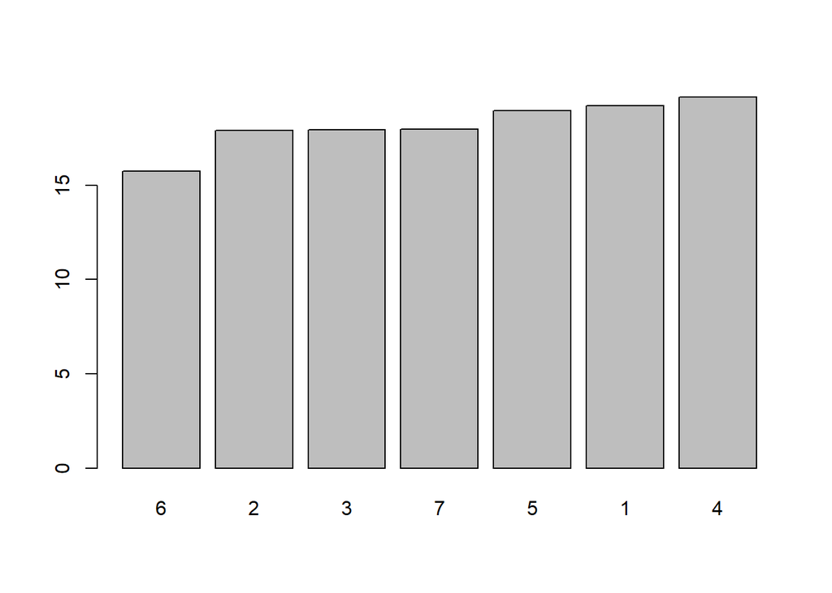

```r
barplot(sort(table(vuelos_delay$DAY_OF_WEEK) / table(vuelos$DAY_OF_WEEK) * 100))
```

```r
table(vuelos_delay$DAY_OF_WEEK) / table(vuelos$DAY_OF_WEEK) * 100
```

```
##
##        1        2        3        4        5        6        7
## 19.20944 17.89995 17.94655 19.67769 18.95608 15.74703 17.96826
```

En esta ocasión obtenemos el resultado esperado: el jueves es el día con mayor % de vuelos retrasados, lo que es lógico al ser el día de la semana con mayor número de vuelos.

Lo que vamos a mostrar en la siguiente gráfica son las franjas horarias donde se producen los retrasos:

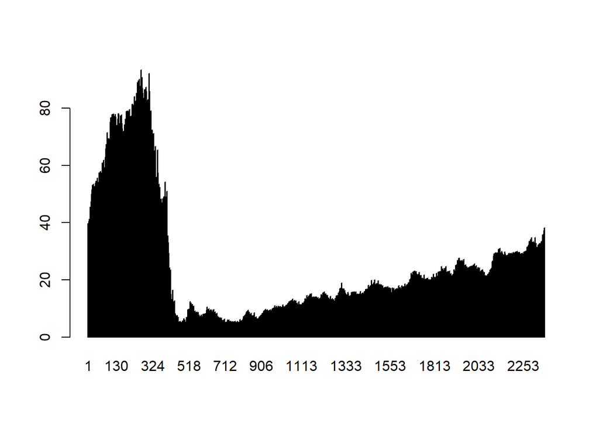

```r
barplot(table(vuelos_delay$ARRIVAL_TIME) / table(vuelos$ARRIVAL_TIME) * 100)
```

Otro dato curioso que podemos obtener es ver el porcentaje de vuelos retrasados según el aeropuerto del que despegan:

```r
t <- sort(table(vuelos_delay$ORIGIN_AIRPORT) / table(vuelos$ORIGIN_AIRPORT) * 100, decreasing = TRUE)

head(t)
```

```
##
##    10165    14222      GST    10154    13964      ADK
## 55.55556 44.44444 44.15584 39.28571 38.88889 38.54167
```

Ahora haremos lo mismo pero según el aeropuerto de destino:

```r
t1 <- sort(table(vuelos_delay$DESTINATION_AIRPORT) / table(vuelos$DESTINATION_AIRPORT) * 100, decreasing = TRUE)

head(t1)
```

```
##
##    13964      STC      PBG      GUM    14025    15070
## 38.88889 36.58537 32.26950 30.83832 30.76923 30.64516
```

# **6. Resolución del problema**

**A partir de los resultados obtenidos, ¿cuáles son las conclusiones? ¿Los resultados permiten responder al problema?**

# **7. Código**

**Adjuntar el código con el que se ha realizado la limpieza, análisis y representación de los datos.**

https://github.com/igonzalezvalle/PRA2---Limpieza-Analisis-Datos/blob/master/src/PRA2-Limpieza-Analisis.R

# **8. Contribuciones al trabajo**

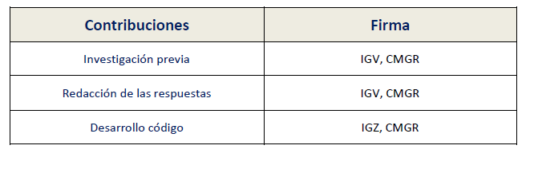

### **Referencias:**

https://rpubs.com  
https://www.kaggle.com/usdot/flight-delays  
https://rstudio-pubs-static.s3.amazonaws.com/326515_e25772acbbba47d98052df5520eed1a4.html  
https://www.r-graph-gallery.com/

- Laia Subirats Maté, Diego Oswaldo Pérez Trenard, Mireia Calvo González. (2019). Introducción a la limpieza de datos.
- Squire, Megan (2015). Clean Data. Packt Publishing Ltd.
- Jiawei Han, Micheine Kamber, Jian Pei (2012). Data mining: concepts and techniques. Morgan Kaufmann.
- Jason W. Osborne (2010). Data Cleaning Basics: Best Practices in Dealing with Extreme Scores. Newborn and Infant Nursing Reviews; 10 (1): pp. 1527-3369.
- Peter Dalgaard (2008). Introductory statistics with R. Springer Science & Business Media. Wes McKinney (2012). Python for Data Analysis. O’Reilley Media, Inc.